# Week 8 – Convolutional Neural Networks with CIFAR-10 (Kaggle)

Author

Published

March 20, 2026

# 1 Dataset Selection

CIFAR-10 data has been chosen to complete this task. The dataset has been retrieved directly from Kaggle at: `https://www.kaggle.com/datasets/petitbonney/cifar10-image-recognition`

# 2 Setup

```r
# install.packages(c("keras3", "png", "ggplot2", "gridExtra"))
library(keras3)
library(png)
library(ggplot2)
library(gridExtra)
```

```r
retail <- read.csv("online_retail_II.csv")
```

```r
library(keras3)

cifar <- dataset_cifar10()

x_train <- cifar$train$x / 255
y_train <- cifar$train$y

x_test  <- cifar$test$x / 255
y_test  <- cifar$test$y

class_names <- c("airplane","automobile","bird","cat","deer",
                 "dog","frog","horse","ship","truck")
```

# 3 Task 1 – Reconnect to the Data

## 3.1 Load Images (Fast — 200 per class)

```r
train_dir   <- "C:/Users/archi/Downloads/cifar10/train"
test_dir    <- "C:/Users/archi/Downloads/cifar10/test"
class_names <- c("airplane", "automobile", "bird", "cat", "deer",
                 "dog", "frog", "horse", "ship", "truck")


# ── Simple fast loader — limits files per class ──
load_images_fast <- function(base_dir, class_names,
                              img_size = 32, max_per_class = 1000) {
  img_list <- list()   # store each image separately
  lb       <- c()

  for (i in seq_along(class_names)) {
    folder <- file.path(base_dir, class_names[i])
    files  <- head(
      list.files(folder, pattern = "\\.png$",
                 full.names = TRUE, ignore.case = TRUE),
      max_per_class
    )
    cat(class_names[i], ":", length(files), "images\n")

    for (f in files) {
      img <- tryCatch(png::readPNG(f), error = function(e) NULL)
      if (is.null(img))                            next
      if (length(dim(img)) == 2)                   img <- array(rep(img, 3), dim = c(dim(img), 3))
      if (dim(img)[3] == 4)                        img <- img[, , 1:3]
      if (!all(dim(img) == c(img_size, img_size, 3))) next

      img_list[[length(img_list) + 1]] <- img  # store whole image
      lb <- c(lb, i - 1L)
    }
  }

  n <- length(lb)
  cat("Total loaded:", n, "\n")
  if (n == 0) stop("No images loaded.")

  # ── Build 4D array correctly — fill image by image ──
  x <- array(0, dim = c(n, img_size, img_size, 3))
  for (j in seq_len(n)) {
    x[j, , , ] <- img_list[[j]]   # each image placed correctly
  }

  list(x = x, y = lb)
}

# Load — takes ~1-2 minutes
cat("--- Training ---\n")
```

```
--- Training ---
```

```r
library(keras3)

library(keras3)
library(png)

cifar <- dataset_cifar10()

save_dir <- "cifar_images"
dir.create(save_dir, showWarnings = FALSE)

class_names <- c("airplane","automobile","bird","cat","deer",
                 "dog","frog","horse","ship","truck")

# Create folders
for (cls in class_names) {
  dir.create(file.path(save_dir, cls), recursive = TRUE, showWarnings = FALSE)
}

# Save first 200 images per class
count <- rep(0, 10)

for (i in 1:50000) {
  label <- cifar$train$y[i] + 1

  if (count[label] >= 200) next

  img <- cifar$train$x[i,,,] / 255

  file_name <- paste0("img_", count[label], ".png")
  writePNG(img, file.path(save_dir, class_names[label], file_name))

  count[label] <- count[label] + 1

  if (all(count >= 200)) break
}
```

## 3.2 Class Distribution

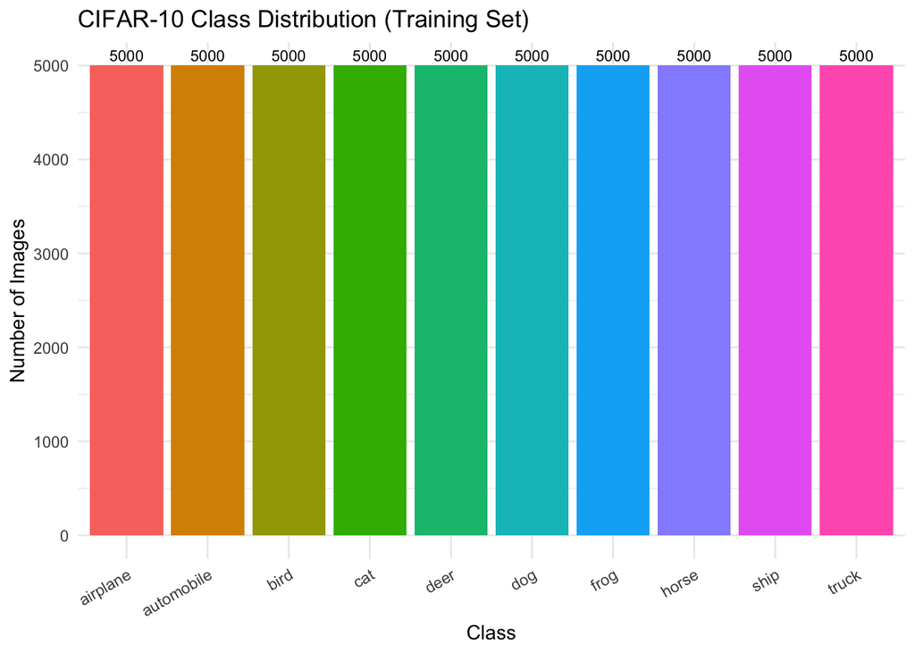

```r
df_counts <- data.frame(
  Class = class_names,
  Count = as.numeric(table(factor(as.vector(y_train), levels = 0:9)))
)

ggplot(df_counts, aes(x = Class, y = Count, fill = Class)) +
  geom_bar(stat = "identity", show.legend = FALSE) +
  geom_text(aes(label = Count), vjust = -0.4, size = 3) +
  labs(title = "CIFAR-10 Class Distribution (Training Set)",
       x = "Class", y = "Number of Images") +
  theme_minimal() +
  theme(axis.text.x = element_text(angle = 30, hjust = 1))
```

## 3.3 One Example Image Per Class

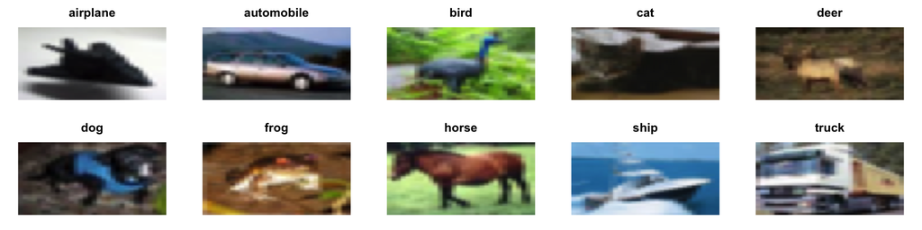

```r
par(mfrow = c(2, 5), mar = c(1, 1, 2, 1))
for (i in 0:9) {
  idx <- which(y_train == i)[1]
  img <- x_train[idx, , , ]
  plot(0:1, 0:1, type = "n", axes = FALSE,
       xlab = "", ylab = "", main = class_names[i + 1])
  rasterImage(img, 0, 0, 1, 1)
}
```

## 3.4 Explanation

**One training example expaination:** Every training sample is represented in a 32x32 PNG image that is coded as a 3D numeric array with the dimensions (height, width, channel). The red, green, and blue channel colours have been normalised to [0, 1]. Collectively, they have trained the visual image of a single real-world object, which is one of the ten CIFAR-10 categories.

**Reason for spatial structure matters:** Items in CIFAR-10 are photographed uniformly across space so that the wings on an aeroplane have been visible at any height, and the legs on a horse are visible at the bottom of the image. These characteristics are local and positional. This has been taken advantage of by the design of convolutional filters, which scan small blocks of pixels in the image and identify edges, textures, and shapes at the point being analysed. The 1D reduction of the picture into a single 1D vector would have ruined all spatial relationships between pixels so that no pattern could have been accurately recognised.

**Wheather a fully connected network would be inefficient:** A three-dimensional flattened (32×32×3) image has 3,072 values. This have involved 3,072×256 eaual to 786,432 weights in a single fully connected layer of 256 neurons. It has been shown that CNNs are much more efficient,where a 3×3 filter inspects 27 weights per channel of any image size, which significantly decreases the number of parameters, and simultaneously, all spatial cues still exist. —

# 4 Task 2 – Baseline CNN

## 4.1 Build, Compile and Train

```r
set.seed(42)
tensorflow::set_random_seed(42)

model_baseline <- keras_model_sequential(name = "Baseline_CNN") |>
  layer_conv_2d(filters = 32, kernel_size = c(3, 3),
                activation = "relu", input_shape = c(32, 32, 3)) |>
  layer_max_pooling_2d(pool_size = c(2, 2)) |>
  layer_flatten() |>
  layer_dense(units = 10, activation = "softmax")

model_baseline |> compile(
  optimizer = "adam",
  loss      = "sparse_categorical_crossentropy",
  metrics   = "accuracy"
)

model_extended <- keras_model_sequential(name = "Extended_CNN") |>
  layer_conv_2d(filters = 32, kernel_size = c(3, 3),
                activation = "relu", input_shape = c(32, 32, 3)) |>
  layer_max_pooling_2d(pool_size = c(2, 2)) |>
  layer_conv_2d(filters = 64, kernel_size = c(3, 3),
                activation = "relu") |>
  layer_max_pooling_2d(pool_size = c(2, 2)) |>
  layer_flatten() |>
  layer_dropout(rate = 0.3) |>
  layer_dense(units = 10, activation = "softmax")

model_extended |> compile(
  optimizer = "adam",
  loss      = "sparse_categorical_crossentropy",
  metrics   = "accuracy"
)

# Shuffle
set.seed(42)
shuffle_idx <- sample(seq_len(dim(x_train)[1]))
x_train_s   <- x_train[shuffle_idx, , , , drop = FALSE]
y_train_s   <- y_train[shuffle_idx]

# Train baseline
history_baseline <- model_baseline |> fit(
  x = x_train_s, y = y_train_s,
  epochs           = 10,
  batch_size       = 32,
  validation_split = 0.2,
  verbose          = 1
)
```

```
   1/1250 ━━━━━━━━━━━━━━━━━━━━ 4:17 206ms/step - accuracy: 0.1250 - loss: 2.3347
  21/1250 ━━━━━━━━━━━━━━━━━━━━ 3s 3ms/step - accuracy: 0.1271 - loss: 2.3115
  43/1250 ━━━━━━━━━━━━━━━━━━━━ 2s 2ms/step - accuracy: 0.1397 - loss: 2.2800
  68/1250 ━━━━━━━━━━━━━━━━━━━━ 2s 2ms/step - accuracy: 0.1617 - loss: 2.2400
  92/1250 ━━━━━━━━━━━━━━━━━━━━ 2s 2ms/step - accuracy: 0.1802 - loss: 2.2036
 116/1250 ━━━━━━━━━━━━━━━━━━━━ 2s 2ms/step - accuracy: 0.1973 - loss: 2.1690
 140/1250 ━━━━━━━━━━━━━━━━━━━━ 2s 2ms/step - accuracy: 0.2121 - loss: 2.1378
 165/1250 ━━━━━━━━━━━━━━━━━━━━ 2s 2ms/step - accuracy: 0.2253 - loss: 2.1092
 190/1250 ━━━━━━━━━━━━━━━━━━━━ 2s 2ms/step - accuracy: 0.2368 - loss: 2.0837
 215/1250 ━━━━━━━━━━━━━━━━━━━━ 2s 2ms/step - accuracy: 0.2474 - loss: 2.0600
 240/1250 ━━━━━━━━━━━━━━━━━━━━ 2s 2ms/step - accuracy: 0.2571 - loss: 2.0382
 264/1250 ━━━━━━━━━━━━━━━━━━━━ 2s 2ms/step - accuracy: 0.2658 - loss: 2.0184
 289/1250 ━━━━━━━━━━━━━━━━━━━━ 2s 2ms/step - accuracy: 0.2741 - loss: 1.9996
 314/1250 ━━━━━━━━━━━━━━━━━━━━ 1s 2ms/step - accuracy: 0.2816 - loss: 1.9823
 339/1250 ━━━━━━━━━━━━━━━━━━━━ 1s 2ms/step - accuracy: 0.2887 - loss: 1.9659
 364/1250 ━━━━━━━━━━━━━━━━━━━━ 1s 2ms/step - accuracy: 0.2951 - loss: 1.9507
 389/1250 ━━━━━━━━━━━━━━━━━━━━ 1s 2ms/step - accuracy: 0.3011 - loss: 1.9363
 414/1250 ━━━━━━━━━━━━━━━━━━━━ 1s 2ms/step - accuracy: 0.3065 - loss: 1.9227
 439/1250 ━━━━━━━━━━━━━━━━━━━━ 1s 2ms/step - accuracy: 0.3117 - loss: 1.9099
 465/1250 ━━━━━━━━━━━━━━━━━━━━ 1s 2ms/step - accuracy: 0.3166 - loss: 1.8975
 490/1250 ━━━━━━━━━━━━━━━━━━━━ 1s 2ms/step - accuracy: 0.3211 - loss: 1.8863
 515/1250 ━━━━━━━━━━━━━━━━━━━━ 1s 2ms/step - accuracy: 0.3254 - loss: 1.8756
 540/1250 ━━━━━━━━━━━━━━━━━━━━ 1s 2ms/step - accuracy: 0.3295 - loss: 1.8653
 565/1250 ━━━━━━━━━━━━━━━━━━━━ 1s 2ms/step - accuracy: 0.3333 - loss: 1.8555
 590/1250 ━━━━━━━━━━━━━━━━━━━━ 1s 2ms/step - accuracy: 0.3370 - loss: 1.8463
 615/1250 ━━━━━━━━━━━━━━━━━━━━ 1s 2ms/step - accuracy: 0.3405 - loss: 1.8373
 640/1250 ━━━━━━━━━━━━━━━━━━━━ 1s 2ms/step - accuracy: 0.3439 - loss: 1.8287
 665/1250 ━━━━━━━━━━━━━━━━━━━━ 1s 2ms/step - accuracy: 0.3472 - loss: 1.8205
 691/1250 ━━━━━━━━━━━━━━━━━━━━ 1s 2ms/step - accuracy: 0.3504 - loss: 1.8124
 716/1250 ━━━━━━━━━━━━━━━━━━━━ 1s 2ms/step - accuracy: 0.3534 - loss: 1.8048
 741/1250 ━━━━━━━━━━━━━━━━━━━━ 1s 2ms/step - accuracy: 0.3563 - loss: 1.7976
 766/1250 ━━━━━━━━━━━━━━━━━━━━ 0s 2ms/step - accuracy: 0.3590 - loss: 1.7905
 792/1250 ━━━━━━━━━━━━━━━━━━━━ 0s 2ms/step - accuracy: 0.3618 - loss: 1.7835
 818/1250 ━━━━━━━━━━━━━━━━━━━━ 0s 2ms/step - accuracy: 0.3645 - loss: 1.7768
 844/1250 ━━━━━━━━━━━━━━━━━━━━ 0s 2ms/step - accuracy: 0.3671 - loss: 1.7702
 870/1250 ━━━━━━━━━━━━━━━━━━━━ 0s 2ms/step - accuracy: 0.3696 - loss: 1.7638
 896/1250 ━━━━━━━━━━━━━━━━━━━━ 0s 2ms/step - accuracy: 0.3720 - loss: 1.7577
 921/1250 ━━━━━━━━━━━━━━━━━━━━ 0s 2ms/step - accuracy: 0.3742 - loss: 1.7521
 947/1250 ━━━━━━━━━━━━━━━━━━━━ 0s 2ms/step - accuracy: 0.3764 - loss: 1.7464
 973/1250 ━━━━━━━━━━━━━━━━━━━━ 0s 2ms/step - accuracy: 0.3786 - loss: 1.7408
```

[output cut: 456 more lines]

```
 901/1250 ━━━━━━━━━━━━━━━━━━━━ 0s 2ms/step - accuracy: 0.7212 - loss: 0.8103
 927/1250 ━━━━━━━━━━━━━━━━━━━━ 0s 2ms/step - accuracy: 0.7213 - loss: 0.8104
 953/1250 ━━━━━━━━━━━━━━━━━━━━ 0s 2ms/step - accuracy: 0.7213 - loss: 0.8103
 979/1250 ━━━━━━━━━━━━━━━━━━━━ 0s 2ms/step - accuracy: 0.7214 - loss: 0.8102
1004/1250 ━━━━━━━━━━━━━━━━━━━━ 0s 2ms/step - accuracy: 0.7215 - loss: 0.8102
1029/1250 ━━━━━━━━━━━━━━━━━━━━ 0s 2ms/step - accuracy: 0.7215 - loss: 0.8101
1055/1250 ━━━━━━━━━━━━━━━━━━━━ 0s 2ms/step - accuracy: 0.7216 - loss: 0.8100
1080/1250 ━━━━━━━━━━━━━━━━━━━━ 0s 2ms/step - accuracy: 0.7217 - loss: 0.8098
1106/1250 ━━━━━━━━━━━━━━━━━━━━ 0s 2ms/step - accuracy: 0.7218 - loss: 0.8097
1131/1250 ━━━━━━━━━━━━━━━━━━━━ 0s 2ms/step - accuracy: 0.7218 - loss: 0.8096
1156/1250 ━━━━━━━━━━━━━━━━━━━━ 0s 2ms/step - accuracy: 0.7219 - loss: 0.8095
1182/1250 ━━━━━━━━━━━━━━━━━━━━ 0s 2ms/step - accuracy: 0.7219 - loss: 0.8094
1207/1250 ━━━━━━━━━━━━━━━━━━━━ 0s 2ms/step - accuracy: 0.7220 - loss: 0.8092
1233/1250 ━━━━━━━━━━━━━━━━━━━━ 0s 2ms/step - accuracy: 0.7221 - loss: 0.8091
1250/1250 ━━━━━━━━━━━━━━━━━━━━ 3s 2ms/step - accuracy: 0.7249 - loss: 0.8039 - val_accuracy: 0.6175 - val_loss: 1.1581
```

```r
# Train extended
history_extended <- model_extended |> fit(
  x = x_train_s, y = y_train_s,
  epochs           = 10,
  batch_size       = 32,
  validation_split = 0.2,
  verbose          = 1
)
```

```
   1/1250 ━━━━━━━━━━━━━━━━━━━━ 5:21 258ms/step - accuracy: 0.1250 - loss: 2.2936
  13/1250 ━━━━━━━━━━━━━━━━━━━━ 5s 4ms/step - accuracy: 0.1099 - loss: 2.3122
  25/1250 ━━━━━━━━━━━━━━━━━━━━ 5s 4ms/step - accuracy: 0.1105 - loss: 2.3106
  38/1250 ━━━━━━━━━━━━━━━━━━━━ 5s 4ms/step - accuracy: 0.1139 - loss: 2.3065
  51/1250 ━━━━━━━━━━━━━━━━━━━━ 4s 4ms/step - accuracy: 0.1190 - loss: 2.3004
  64/1250 ━━━━━━━━━━━━━━━━━━━━ 4s 4ms/step - accuracy: 0.1264 - loss: 2.2915
  77/1250 ━━━━━━━━━━━━━━━━━━━━ 4s 4ms/step - accuracy: 0.1340 - loss: 2.2802
  90/1250 ━━━━━━━━━━━━━━━━━━━━ 4s 4ms/step - accuracy: 0.1414 - loss: 2.2678
 102/1250 ━━━━━━━━━━━━━━━━━━━━ 4s 4ms/step - accuracy: 0.1483 - loss: 2.2553
 114/1250 ━━━━━━━━━━━━━━━━━━━━ 4s 4ms/step - accuracy: 0.1554 - loss: 2.2418
 126/1250 ━━━━━━━━━━━━━━━━━━━━ 4s 4ms/step - accuracy: 0.1622 - loss: 2.2281
 138/1250 ━━━━━━━━━━━━━━━━━━━━ 4s 4ms/step - accuracy: 0.1685 - loss: 2.2150
 149/1250 ━━━━━━━━━━━━━━━━━━━━ 4s 4ms/step - accuracy: 0.1739 - loss: 2.2035
 161/1250 ━━━━━━━━━━━━━━━━━━━━ 4s 4ms/step - accuracy: 0.1794 - loss: 2.1914
 174/1250 ━━━━━━━━━━━━━━━━━━━━ 4s 4ms/step - accuracy: 0.1849 - loss: 2.1789
 186/1250 ━━━━━━━━━━━━━━━━━━━━ 4s 4ms/step - accuracy: 0.1899 - loss: 2.1680
 198/1250 ━━━━━━━━━━━━━━━━━━━━ 4s 4ms/step - accuracy: 0.1947 - loss: 2.1571
 209/1250 ━━━━━━━━━━━━━━━━━━━━ 4s 4ms/step - accuracy: 0.1990 - loss: 2.1475
 221/1250 ━━━━━━━━━━━━━━━━━━━━ 4s 4ms/step - accuracy: 0.2036 - loss: 2.1372
 233/1250 ━━━━━━━━━━━━━━━━━━━━ 4s 4ms/step - accuracy: 0.2081 - loss: 2.1273
 245/1250 ━━━━━━━━━━━━━━━━━━━━ 4s 4ms/step - accuracy: 0.2125 - loss: 2.1177
 257/1250 ━━━━━━━━━━━━━━━━━━━━ 4s 4ms/step - accuracy: 0.2167 - loss: 2.1083
 269/1250 ━━━━━━━━━━━━━━━━━━━━ 4s 4ms/step - accuracy: 0.2208 - loss: 2.0992
 281/1250 ━━━━━━━━━━━━━━━━━━━━ 4s 4ms/step - accuracy: 0.2246 - loss: 2.0906
 293/1250 ━━━━━━━━━━━━━━━━━━━━ 4s 4ms/step - accuracy: 0.2282 - loss: 2.0822
 305/1250 ━━━━━━━━━━━━━━━━━━━━ 4s 4ms/step - accuracy: 0.2316 - loss: 2.0742
 317/1250 ━━━━━━━━━━━━━━━━━━━━ 3s 4ms/step - accuracy: 0.2350 - loss: 2.0664
 329/1250 ━━━━━━━━━━━━━━━━━━━━ 3s 4ms/step - accuracy: 0.2383 - loss: 2.0587
 341/1250 ━━━━━━━━━━━━━━━━━━━━ 3s 4ms/step - accuracy: 0.2415 - loss: 2.0512
 353/1250 ━━━━━━━━━━━━━━━━━━━━ 3s 4ms/step - accuracy: 0.2445 - loss: 2.0439
 365/1250 ━━━━━━━━━━━━━━━━━━━━ 3s 4ms/step - accuracy: 0.2475 - loss: 2.0369
 377/1250 ━━━━━━━━━━━━━━━━━━━━ 3s 4ms/step - accuracy: 0.2504 - loss: 2.0300
 389/1250 ━━━━━━━━━━━━━━━━━━━━ 3s 4ms/step - accuracy: 0.2531 - loss: 2.0232
 401/1250 ━━━━━━━━━━━━━━━━━━━━ 3s 4ms/step - accuracy: 0.2558 - loss: 2.0166
 413/1250 ━━━━━━━━━━━━━━━━━━━━ 3s 4ms/step - accuracy: 0.2584 - loss: 2.0102
 425/1250 ━━━━━━━━━━━━━━━━━━━━ 3s 4ms/step - accuracy: 0.2610 - loss: 2.0040
 437/1250 ━━━━━━━━━━━━━━━━━━━━ 3s 4ms/step - accuracy: 0.2634 - loss: 1.9980
 449/1250 ━━━━━━━━━━━━━━━━━━━━ 3s 4ms/step - accuracy: 0.2658 - loss: 1.9922
 461/1250 ━━━━━━━━━━━━━━━━━━━━ 3s 4ms/step - accuracy: 0.2681 - loss: 1.9865
 473/1250 ━━━━━━━━━━━━━━━━━━━━ 3s 4ms/step - accuracy: 0.2704 - loss: 1.9810
```

[output cut: 1035 more lines]

```
1097/1250 ━━━━━━━━━━━━━━━━━━━━ 0s 5ms/step - accuracy: 0.6908 - loss: 0.8906
1109/1250 ━━━━━━━━━━━━━━━━━━━━ 0s 5ms/step - accuracy: 0.6908 - loss: 0.8906
1120/1250 ━━━━━━━━━━━━━━━━━━━━ 0s 5ms/step - accuracy: 0.6908 - loss: 0.8906
1132/1250 ━━━━━━━━━━━━━━━━━━━━ 0s 5ms/step - accuracy: 0.6908 - loss: 0.8906
1144/1250 ━━━━━━━━━━━━━━━━━━━━ 0s 5ms/step - accuracy: 0.6908 - loss: 0.8906
1156/1250 ━━━━━━━━━━━━━━━━━━━━ 0s 5ms/step - accuracy: 0.6908 - loss: 0.8906
1167/1250 ━━━━━━━━━━━━━━━━━━━━ 0s 5ms/step - accuracy: 0.6908 - loss: 0.8906
1179/1250 ━━━━━━━━━━━━━━━━━━━━ 0s 5ms/step - accuracy: 0.6908 - loss: 0.8906
1191/1250 ━━━━━━━━━━━━━━━━━━━━ 0s 5ms/step - accuracy: 0.6908 - loss: 0.8906
1202/1250 ━━━━━━━━━━━━━━━━━━━━ 0s 5ms/step - accuracy: 0.6908 - loss: 0.8906
1214/1250 ━━━━━━━━━━━━━━━━━━━━ 0s 5ms/step - accuracy: 0.6908 - loss: 0.8906
1225/1250 ━━━━━━━━━━━━━━━━━━━━ 0s 5ms/step - accuracy: 0.6908 - loss: 0.8906
1236/1250 ━━━━━━━━━━━━━━━━━━━━ 0s 5ms/step - accuracy: 0.6908 - loss: 0.8905
1247/1250 ━━━━━━━━━━━━━━━━━━━━ 0s 5ms/step - accuracy: 0.6908 - loss: 0.8905
1250/1250 ━━━━━━━━━━━━━━━━━━━━ 6s 5ms/step - accuracy: 0.6922 - loss: 0.8877 - val_accuracy: 0.6868 - val_loss: 0.9144
```

## 4.2 Explanation

**Convolution layer learning outcome:** The convolution layer has been set to use 32, 3×3 filters. The individual filters have been trained through the backpropagation algorithm to respond to a single low-level visual stimulus- a vertical line, a colour gradient, or a diagonal line. These have produced 32 feature maps, spatially encoding which of its patterns has been identified in the picture.

**The role of pooling:** The application of the max pooling has been used to cut the spatial dimensions of 30x30 to 15x15 by maintaining only the strongest activation in every 2x2 window. The number of parameters in the dense layer before entry has been lower, and the model has been made to be tolerant of small positional changes in patterns found in the model.

**Trainable parameters:**

- Conv layer: (3×3×3 + 1) × 32 = **896 parameters**
- Dense output: (15×15×32 × 10) + 10 = **72,010 parameters**

# 5 Task 3 – Architectural Extension

## 5.1 Modifications Made

**Two changes** have been introduced to extend the baseline:

1. **A second convolutional layer has been added** (64 filters, 3×3) to learn higher-order combinations of patterns from the first layer.
2. **Dropout (rate = 0.3) has been added** after flattening, to reduce overfitting by randomly deactivating 30% of neurons per step.

## 5.2 Build, Compile and Train

```r
model_extended <- keras_model_sequential(name = "Extended_CNN") |>
  layer_conv_2d(filters = 32, kernel_size = c(3, 3),
                activation = "relu", input_shape = c(32, 32, 3)) |>
  layer_max_pooling_2d(pool_size = c(2, 2)) |>
  layer_conv_2d(filters = 64, kernel_size = c(3, 3),
                activation = "relu") |>
  layer_max_pooling_2d(pool_size = c(2, 2)) |>
  layer_flatten() |>
  layer_dropout(rate = 0.3) |>
  layer_dense(units = 10, activation = "softmax")

summary(model_extended)
```

```
Model: "Extended_CNN"
┏━━━━━━━━━━━━━━━━━━━━━━━━━━━━━━━━━━━┳━━━━━━━━━━━━━━━━━━━━━━━━━━┳━━━━━━━━━━━━━━━┓
┃ Layer (type)                      ┃ Output Shape             ┃       Param # ┃
┡━━━━━━━━━━━━━━━━━━━━━━━━━━━━━━━━━━━╇━━━━━━━━━━━━━━━━━━━━━━━━━━╇━━━━━━━━━━━━━━━┩
│ conv2d_3 (Conv2D)                 │ (None, 30, 30, 32)       │           896 │
├───────────────────────────────────┼──────────────────────────┼───────────────┤
│ max_pooling2d_3 (MaxPooling2D)    │ (None, 15, 15, 32)       │             0 │
├───────────────────────────────────┼──────────────────────────┼───────────────┤
│ conv2d_4 (Conv2D)                 │ (None, 13, 13, 64)       │        18,496 │
├───────────────────────────────────┼──────────────────────────┼───────────────┤
│ max_pooling2d_4 (MaxPooling2D)    │ (None, 6, 6, 64)         │             0 │
├───────────────────────────────────┼──────────────────────────┼───────────────┤
│ flatten_2 (Flatten)               │ (None, 2304)             │             0 │
├───────────────────────────────────┼──────────────────────────┼───────────────┤
│ dropout_1 (Dropout)               │ (None, 2304)             │             0 │
├───────────────────────────────────┼──────────────────────────┼───────────────┤
│ dense_2 (Dense)                   │ (None, 10)               │        23,050 │
└───────────────────────────────────┴──────────────────────────┴───────────────┘
 Total params: 42,442 (165.79 KB)
 Trainable params: 42,442 (165.79 KB)
 Non-trainable params: 0 (0.00 B)
```

```r
model_extended |> compile(
  optimizer = "adam",
  loss      = "sparse_categorical_crossentropy",
  metrics   = "accuracy"
)

history_extended <- model_extended |> fit(
  x = x_train, y = y_train,
  epochs           = 10,
  batch_size       = 32,
  validation_split = 0.2,
  verbose          = 1
)
```

```
   1/1250 ━━━━━━━━━━━━━━━━━━━━ 5:38 271ms/step - accuracy: 0.0938 - loss: 2.3318
  12/1250 ━━━━━━━━━━━━━━━━━━━━ 6s 5ms/step - accuracy: 0.1036 - loss: 2.3295
  24/1250 ━━━━━━━━━━━━━━━━━━━━ 5s 5ms/step - accuracy: 0.1121 - loss: 2.3154
  36/1250 ━━━━━━━━━━━━━━━━━━━━ 5s 5ms/step - accuracy: 0.1203 - loss: 2.3036
  47/1250 ━━━━━━━━━━━━━━━━━━━━ 5s 5ms/step - accuracy: 0.1261 - loss: 2.2933
  59/1250 ━━━━━━━━━━━━━━━━━━━━ 5s 4ms/step - accuracy: 0.1327 - loss: 2.2819
  70/1250 ━━━━━━━━━━━━━━━━━━━━ 5s 5ms/step - accuracy: 0.1388 - loss: 2.2709
  82/1250 ━━━━━━━━━━━━━━━━━━━━ 5s 4ms/step - accuracy: 0.1448 - loss: 2.2591
  93/1250 ━━━━━━━━━━━━━━━━━━━━ 5s 5ms/step - accuracy: 0.1503 - loss: 2.2486
 104/1250 ━━━━━━━━━━━━━━━━━━━━ 5s 5ms/step - accuracy: 0.1559 - loss: 2.2378
 116/1250 ━━━━━━━━━━━━━━━━━━━━ 5s 5ms/step - accuracy: 0.1618 - loss: 2.2259
 128/1250 ━━━━━━━━━━━━━━━━━━━━ 5s 5ms/step - accuracy: 0.1676 - loss: 2.2143
 140/1250 ━━━━━━━━━━━━━━━━━━━━ 4s 4ms/step - accuracy: 0.1732 - loss: 2.2030
 152/1250 ━━━━━━━━━━━━━━━━━━━━ 4s 4ms/step - accuracy: 0.1786 - loss: 2.1917
 164/1250 ━━━━━━━━━━━━━━━━━━━━ 4s 4ms/step - accuracy: 0.1838 - loss: 2.1809
 176/1250 ━━━━━━━━━━━━━━━━━━━━ 4s 4ms/step - accuracy: 0.1890 - loss: 2.1702
 187/1250 ━━━━━━━━━━━━━━━━━━━━ 4s 5ms/step - accuracy: 0.1935 - loss: 2.1607
 199/1250 ━━━━━━━━━━━━━━━━━━━━ 4s 5ms/step - accuracy: 0.1983 - loss: 2.1506
 211/1250 ━━━━━━━━━━━━━━━━━━━━ 4s 4ms/step - accuracy: 0.2029 - loss: 2.1407
 223/1250 ━━━━━━━━━━━━━━━━━━━━ 4s 4ms/step - accuracy: 0.2073 - loss: 2.1311
 235/1250 ━━━━━━━━━━━━━━━━━━━━ 4s 4ms/step - accuracy: 0.2116 - loss: 2.1218
 247/1250 ━━━━━━━━━━━━━━━━━━━━ 4s 4ms/step - accuracy: 0.2156 - loss: 2.1128
 258/1250 ━━━━━━━━━━━━━━━━━━━━ 4s 5ms/step - accuracy: 0.2192 - loss: 2.1048
 270/1250 ━━━━━━━━━━━━━━━━━━━━ 4s 5ms/step - accuracy: 0.2230 - loss: 2.0963
 281/1250 ━━━━━━━━━━━━━━━━━━━━ 4s 5ms/step - accuracy: 0.2264 - loss: 2.0888
 293/1250 ━━━━━━━━━━━━━━━━━━━━ 4s 5ms/step - accuracy: 0.2299 - loss: 2.0809
 304/1250 ━━━━━━━━━━━━━━━━━━━━ 4s 5ms/step - accuracy: 0.2330 - loss: 2.0740
 316/1250 ━━━━━━━━━━━━━━━━━━━━ 4s 5ms/step - accuracy: 0.2363 - loss: 2.0667
 327/1250 ━━━━━━━━━━━━━━━━━━━━ 4s 5ms/step - accuracy: 0.2392 - loss: 2.0602
 338/1250 ━━━━━━━━━━━━━━━━━━━━ 4s 5ms/step - accuracy: 0.2421 - loss: 2.0538
 350/1250 ━━━━━━━━━━━━━━━━━━━━ 4s 5ms/step - accuracy: 0.2450 - loss: 2.0470
 362/1250 ━━━━━━━━━━━━━━━━━━━━ 4s 5ms/step - accuracy: 0.2479 - loss: 2.0405
 374/1250 ━━━━━━━━━━━━━━━━━━━━ 3s 5ms/step - accuracy: 0.2507 - loss: 2.0341
 385/1250 ━━━━━━━━━━━━━━━━━━━━ 3s 5ms/step - accuracy: 0.2531 - loss: 2.0284
 397/1250 ━━━━━━━━━━━━━━━━━━━━ 3s 5ms/step - accuracy: 0.2557 - loss: 2.0225
 409/1250 ━━━━━━━━━━━━━━━━━━━━ 3s 5ms/step - accuracy: 0.2582 - loss: 2.0167
 421/1250 ━━━━━━━━━━━━━━━━━━━━ 3s 5ms/step - accuracy: 0.2606 - loss: 2.0110
 433/1250 ━━━━━━━━━━━━━━━━━━━━ 3s 5ms/step - accuracy: 0.2630 - loss: 2.0055
 445/1250 ━━━━━━━━━━━━━━━━━━━━ 3s 5ms/step - accuracy: 0.2653 - loss: 2.0002
 457/1250 ━━━━━━━━━━━━━━━━━━━━ 3s 5ms/step - accuracy: 0.2675 - loss: 1.9950
```

[output cut: 1105 more lines]

```
1118/1250 ━━━━━━━━━━━━━━━━━━━━ 0s 5ms/step - accuracy: 0.6931 - loss: 0.8858
1127/1250 ━━━━━━━━━━━━━━━━━━━━ 0s 5ms/step - accuracy: 0.6931 - loss: 0.8857
1137/1250 ━━━━━━━━━━━━━━━━━━━━ 0s 5ms/step - accuracy: 0.6932 - loss: 0.8857
1147/1250 ━━━━━━━━━━━━━━━━━━━━ 0s 5ms/step - accuracy: 0.6932 - loss: 0.8857
1157/1250 ━━━━━━━━━━━━━━━━━━━━ 0s 5ms/step - accuracy: 0.6932 - loss: 0.8856
1168/1250 ━━━━━━━━━━━━━━━━━━━━ 0s 5ms/step - accuracy: 0.6933 - loss: 0.8855
1178/1250 ━━━━━━━━━━━━━━━━━━━━ 0s 5ms/step - accuracy: 0.6933 - loss: 0.8855
1188/1250 ━━━━━━━━━━━━━━━━━━━━ 0s 5ms/step - accuracy: 0.6933 - loss: 0.8854
1197/1250 ━━━━━━━━━━━━━━━━━━━━ 0s 5ms/step - accuracy: 0.6933 - loss: 0.8854
1207/1250 ━━━━━━━━━━━━━━━━━━━━ 0s 5ms/step - accuracy: 0.6934 - loss: 0.8853
1218/1250 ━━━━━━━━━━━━━━━━━━━━ 0s 5ms/step - accuracy: 0.6934 - loss: 0.8853
1229/1250 ━━━━━━━━━━━━━━━━━━━━ 0s 5ms/step - accuracy: 0.6934 - loss: 0.8852
1239/1250 ━━━━━━━━━━━━━━━━━━━━ 0s 5ms/step - accuracy: 0.6935 - loss: 0.8852
1249/1250 ━━━━━━━━━━━━━━━━━━━━ 0s 5ms/step - accuracy: 0.6935 - loss: 0.8851
1250/1250 ━━━━━━━━━━━━━━━━━━━━ 7s 5ms/step - accuracy: 0.6973 - loss: 0.8788 - val_accuracy: 0.6932 - val_loss: 0.9068
```

## 5.3 Justification

**Expected performance improvement :** The second convolutional layer has been inserted in a manner that it takes feature maps as inputs of the first layer as opposed to raw pixels, which allows it to detect higher-level features like the outlines of the objects and the texture combinations. The dropout method of regularisation has also been proposed as a method that has been repeatedly proven to minimise overfitting by ensuring that neurons do not overadapt to one another throughout training.

# 6 Task 4 – Training Behaviour Analysis

## 6.1 Training Curves – Baseline CNN

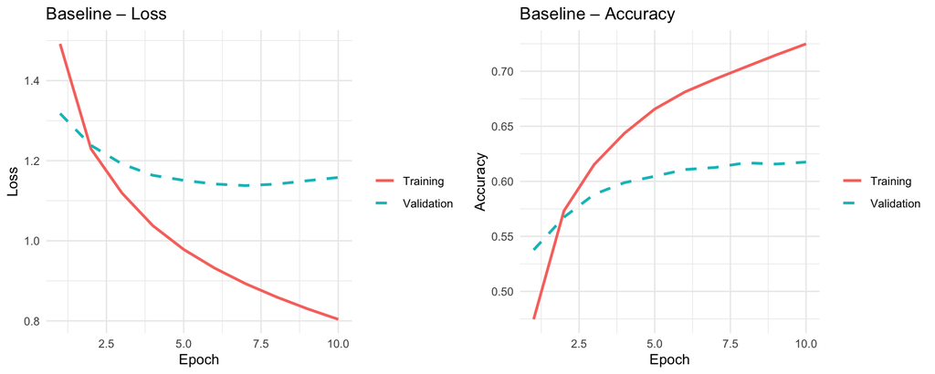

```r
df_base <- data.frame(
  epoch      = 1:10,
  train_loss = history_baseline$metrics$loss,
  val_loss   = history_baseline$metrics$val_loss,
  train_acc  = history_baseline$metrics$accuracy,
  val_acc    = history_baseline$metrics$val_accuracy
)

p1 <- ggplot(df_base, aes(x = epoch)) +
  geom_line(aes(y = train_loss, colour = "Training"),   linewidth = 1) +
  geom_line(aes(y = val_loss,   colour = "Validation"), linewidth = 1,
            linetype = "dashed") +
  labs(title = "Baseline – Loss", x = "Epoch",
       y = "Loss", colour = "") + theme_minimal()

p2 <- ggplot(df_base, aes(x = epoch)) +
  geom_line(aes(y = train_acc, colour = "Training"),   linewidth = 1) +
  geom_line(aes(y = val_acc,   colour = "Validation"), linewidth = 1,
            linetype = "dashed") +
  labs(title = "Baseline – Accuracy", x = "Epoch",
       y = "Accuracy", colour = "") + theme_minimal()

grid.arrange(p1, p2, ncol = 2)
```

## 6.2 Training Curves – Extended CNN

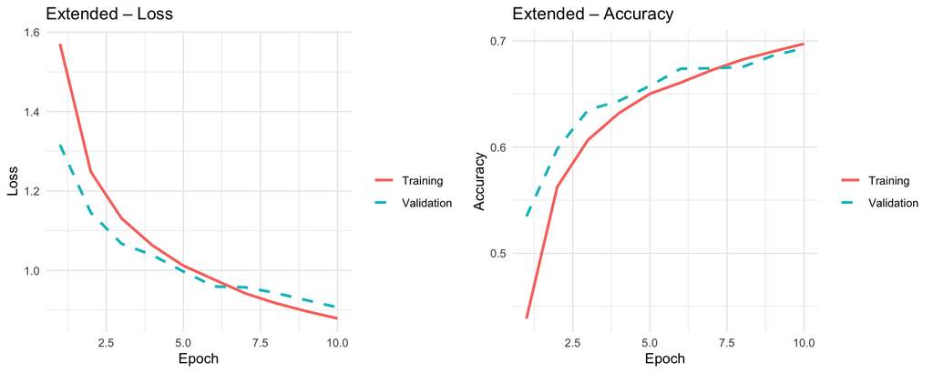

```r
df_ext <- data.frame(
  epoch      = 1:10,
  train_loss = history_extended$metrics$loss,
  val_loss   = history_extended$metrics$val_loss,
  train_acc  = history_extended$metrics$accuracy,
  val_acc    = history_extended$metrics$val_accuracy
)

p3 <- ggplot(df_ext, aes(x = epoch)) +
  geom_line(aes(y = train_loss, colour = "Training"),   linewidth = 1) +
  geom_line(aes(y = val_loss,   colour = "Validation"), linewidth = 1,
            linetype = "dashed") +
  labs(title = "Extended – Loss", x = "Epoch",
       y = "Loss", colour = "") + theme_minimal()

p4 <- ggplot(df_ext, aes(x = epoch)) +
  geom_line(aes(y = train_acc, colour = "Training"),   linewidth = 1) +
  geom_line(aes(y = val_acc,   colour = "Validation"), linewidth = 1,
            linetype = "dashed") +
  labs(title = "Extended – Accuracy", x = "Epoch",
       y = "Accuracy", colour = "") + theme_minimal()

grid.arrange(p3, p4, ncol = 2)
```